# Reproducible Research Project 1

## Loading and preprocessing Data By Downloading the Dataset

### Part 1: Load the Data

```r
# Download the dataset
fileUrl <- "https://d396qusza40orc.cloudfront.net/repdata%2Fdata%2Factivity.zip"
# Create a data directory if it doesn't exist
if (!file.exists("./data")) {
    dir.create("./data")
}
# check if activity.zip file exists
if (!file.exists("./data/activity.zip")) {
    download.file(fileUrl, destfile = "./data/activity.zip")
}
# check if activity.csv file exists
if (!file.exists("./data/activity.csv")) {
    unzip("./data/activity.zip", exdir = "./data")
}
# Read the data
activity <- read.csv("./data/activity.csv")
```

### Part 2 Process/transform the data

**Task 1: What is mean total number of steps taken per day?**  
1. Calculate the total number of steps taken per day.

2. Make a histogram of the total number of steps taken each day.

3. Calculate and report the mean and median of the total number of steps taken per day.

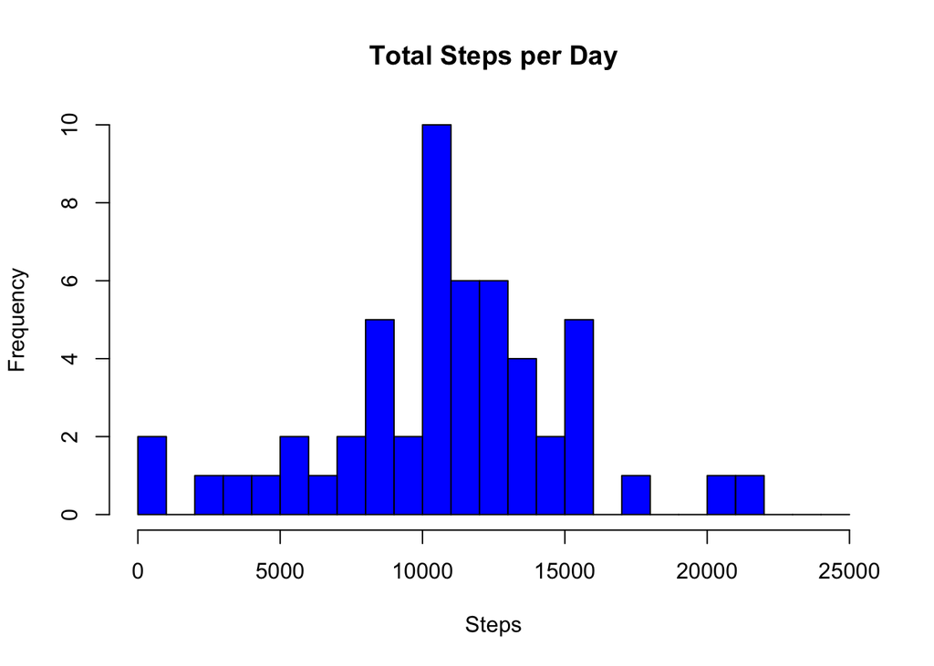

```r
# Calculate the total number of steps taken per day
totalSteps <- aggregate(steps ~ date, data = activity, sum, na.rm = TRUE)
# Make a histogram of the total number of steps taken each day
hist(totalSteps$steps, breaks = seq(0, 25000, by = 1000), col = "blue", xlab = "Steps",
    main = "Total Steps per Day")
```

```r
# Calculate and report the mean and median of the total number of steps taken per day
mean(totalSteps$steps)
```

```
## [1] 10766.19
```

```r
median(totalSteps$steps)
```

```
## [1] 10765
```

**Task 2: What is the average daily activity pattern?**

1. Make a time series plot (i.e. type = “l”) of the 5-minute interval (x-axis) and the average number of steps taken, averaged across all days (y-axis)
2. Which 5-minute interval, on average across all the days in the dataset, contains the maximum number of steps?

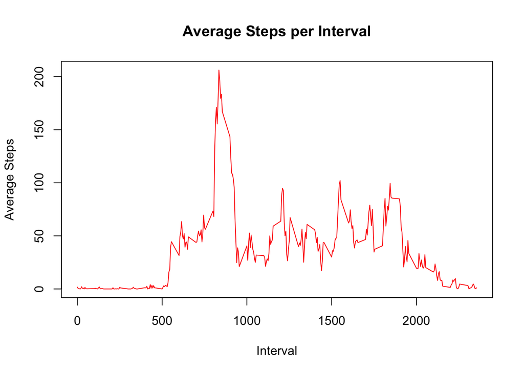

```r
# Make a time series plot (i.e. type = "l") of the 5-minute interval (x-axis)
# and the average number of steps taken, averaged across all days (y-axis)
averageSteps <- aggregate(steps ~ interval, data = activity, mean, na.rm = TRUE)
plot(averageSteps$interval, averageSteps$steps, type = "l", main = "Average Steps per Interval", xlab = "Interval", ylab = "Average Steps", col = "red")
```

```r
# Which 5-minute interval, on average across all the days in the dataset, contains the maximum number of steps?
averageSteps[which.max(averageSteps$steps), ]$interval
```

```
## [1] 835
```

**Task 3: Imputing missing values**

```r
library(dplyr)
# Calculate and report the total number of missing values in the dataset (i.e. the total number of rows with NAs)
sum(is.na(activity$steps))
```

```
## [1] 2304
```

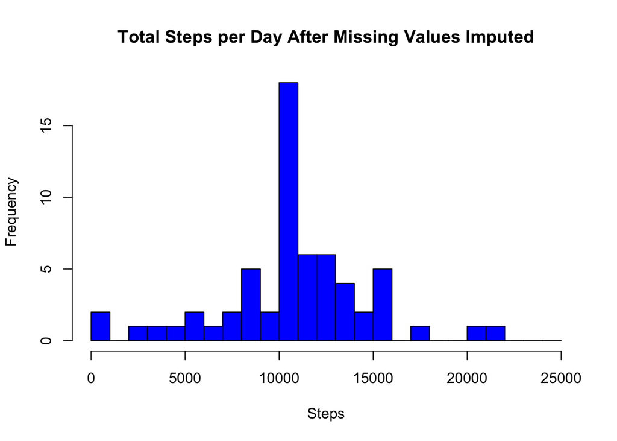

```r
# Devise a strategy for filling in all of the missing values in the dataset.
# In codes below, I use mean value for that 5-minute interval for all days.
# Create a new dataset that is equal to the original dataset but with the missing data filled in.
activityImputed <- activity
activity_missing <- activityImputed[is.na(activityImputed$steps), ]
mapped_steps <- merge(activity_missing, averageSteps,by='interval', all.x=TRUE)
# interate activityImputed dataset and replace NA values with mapped_steps$steps by searching same inertval and date
for (i in 1:nrow(activityImputed)) {
    if (is.na(activityImputed$steps[i])) {
        activityImputed$steps[i] <- mapped_steps$steps.y[which(mapped_steps$interval == activityImputed$interval[i] & mapped_steps$date == activityImputed$date[i])]
    }
}
# Create a histogram of the total number of steps taken each day after missing values were imputed

totalStepsImputed <- aggregate(steps ~ date, data = activityImputed, sum)
hist(totalStepsImputed$steps, breaks = seq(0, 25000, by = 1000), col = "blue", xlab = "Steps",
    main = "Total Steps per Day After Missing Values Imputed")
```

**Task 4: Are there differences in activity patterns between weekdays and weekends? For this part the weekdays() function may be of some help here. Use the dataset with the filled-in missing values for this part.**

1. Create a new factor variable in the dataset with two levels – “weekday” and “weekend” indicating whether a given date is a weekday or weekend day.
2. Make a panel plot containing a time series plot (i.e. type = “l”) of the 5-minute interval (x-axis) and the average number of steps taken, averaged across all weekday days or weekend days (y-axis).

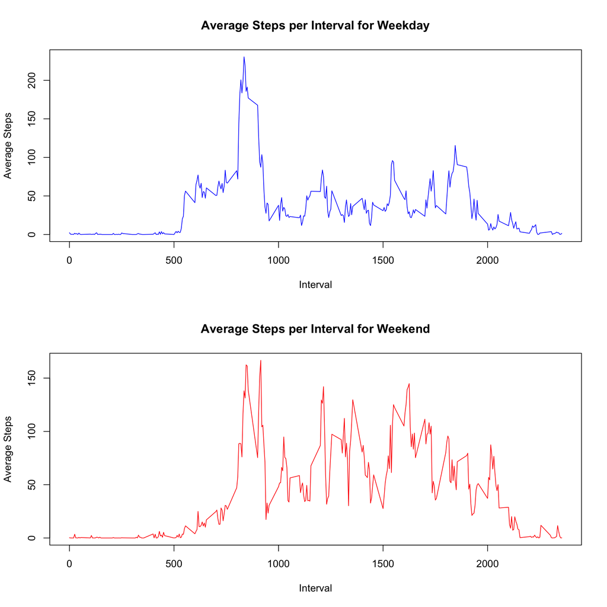

```r
# Create a new factor variable in the dataset with two levels – “weekday” and “weekend”
# indicating whether a given date is a weekday or weekend day.
activityImputed$day <- ifelse(as.POSIXlt(as.Date(activityImputed$date))$wday%%6 ==
    0, "weekend", "weekday")
# Make a panel plot containing a time series plot (i.e. type = “l”) of the 5-minute interval (x-axis)
# and the average number of steps taken, averaged across all weekday days or weekend days (y-axis).

# Create two panel showing plots for weekday and weekend seperatly
par(mfrow = c(2, 1))
# Plot for weekday
averageStepsWeekday <- aggregate(steps ~ interval, data = activityImputed[activityImputed$day ==
    "weekday", ], mean)
plot(averageStepsWeekday$interval, averageStepsWeekday$steps,
    type = "l", main = "Average Steps per Interval for Weekday",
    xlab = "Interval", ylab = "Average Steps", col = "blue"
)
# Plot for weekend
averageStepsWeekend <- aggregate(steps ~ interval, data = activityImputed[activityImputed$day ==
    "weekend", ], mean)
plot(averageStepsWeekend$interval, averageStepsWeekend$steps,
    type = "l", main = "Average Steps per Interval for Weekend",
    xlab = "Interval", ylab = "Average Steps", col = "red"
)
```